# Pràctica 2

### Clustering

```r
# Subset sense les variables classe
wine.x <- wine[,1:10]

# Normalitza el dataframe, ja que està en diferents escales
wine.norm <- as.data.frame(scale(wine.x))
```

Per saber quin és el nombre òptim de clústers en que s’han d’agrupar les dades es pot fer comprovant el valor de la silueta entre 1 i 10 clústers per exemple.

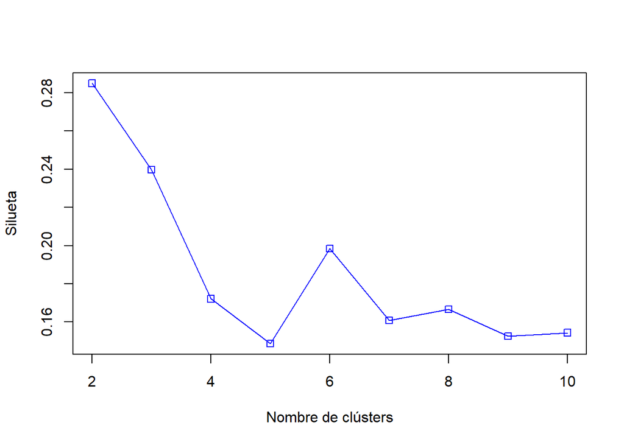

```r
# Mira com queda la silueta entre 1 i 10 clústers
d <- daisy(wine.norm)
resultats <- rep(0, 10)
for (i in 2:10) {
  wine.k        <- kmeans(wine.norm, i)
  winecluster   <- wine.k$cluster
  swc           <- silhouette(winecluster, d)
  resultats[i]  <- mean(swc[,3])
}

# Ho mostra per pantalla visualment
plot(2:10,resultats[2:10],type="o",col="blue",pch=0,xlab="Nombre de clústers",ylab="Silueta")
```

```r
set.seed(10)

# Aplica l'algorisme k-means amb el número òptim de clústers, 2
wine.k2 <- kmeans(wine.norm, 2)

# Mida dels clústers
wine.k2$size
```

```
## [1] 1619 4832
```

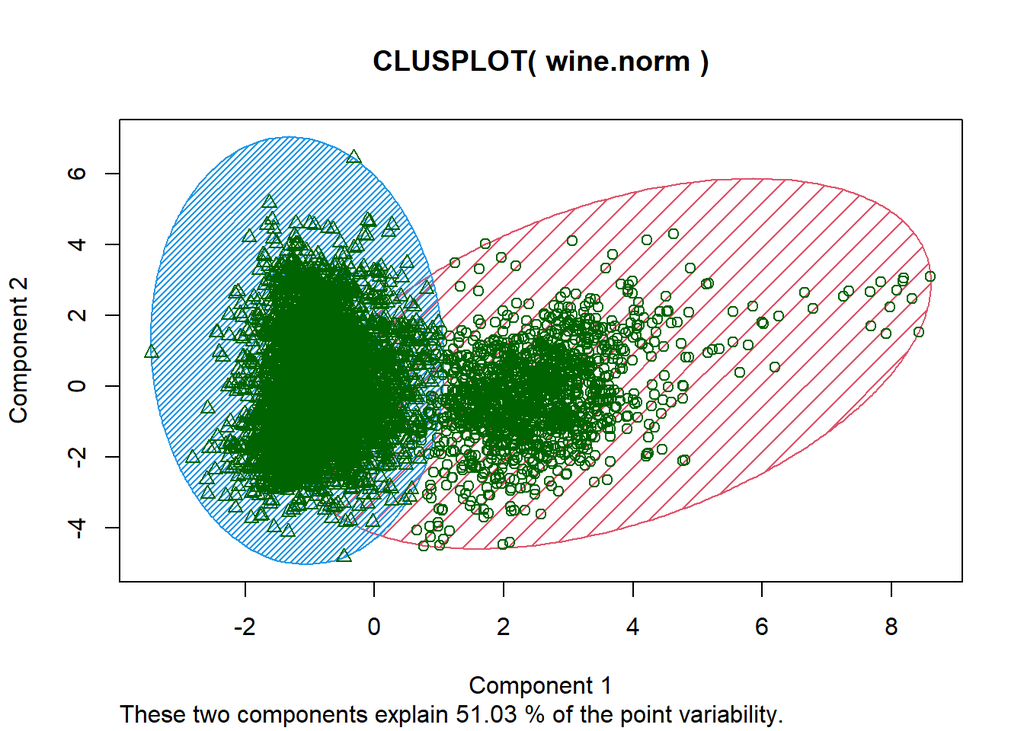

```r
# Vizualitza els clústers
clusplot(wine.norm, wine.k2$cluster, color=TRUE, shade=TRUE, lines=0)
```

- Resultats

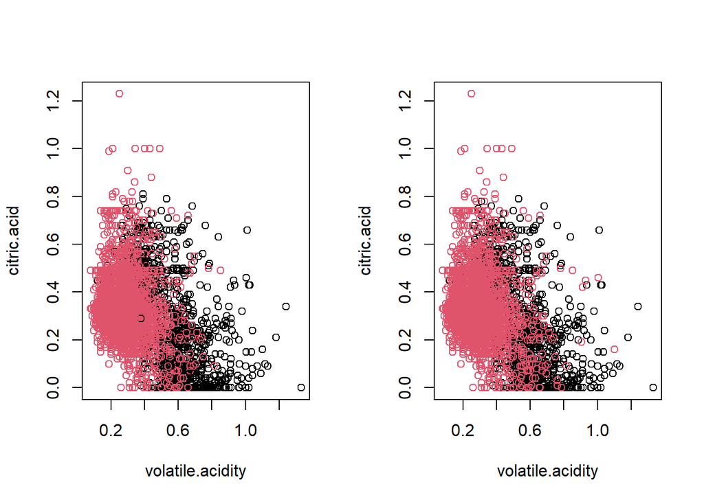

```r
# Comparació visual de com ha agrupat l'algorisme respecte als grups reals
par(mfrow=c(1,2))
plot(wine[c(2,3)], col=wine.k2$cluster)
plot(wine[c(2,3)], col=wine$type)
```

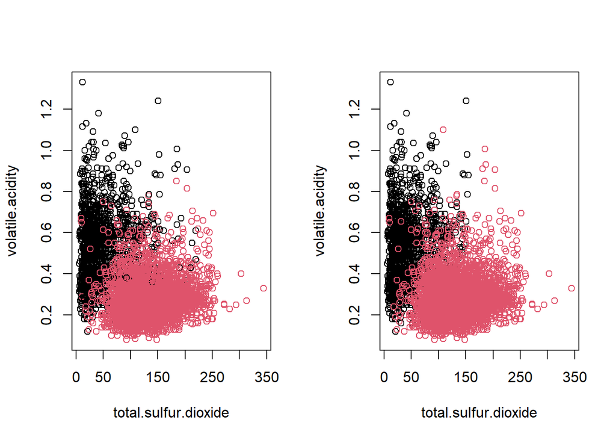

```r
# Comparació visual de com ha agrupat l'algorisme respecte als grups reals
par(mfrow=c(1,2))
plot(wine[c(6,2)], col=wine.k2$cluster)
plot(wine[c(6,2)], col=wine$type)
```

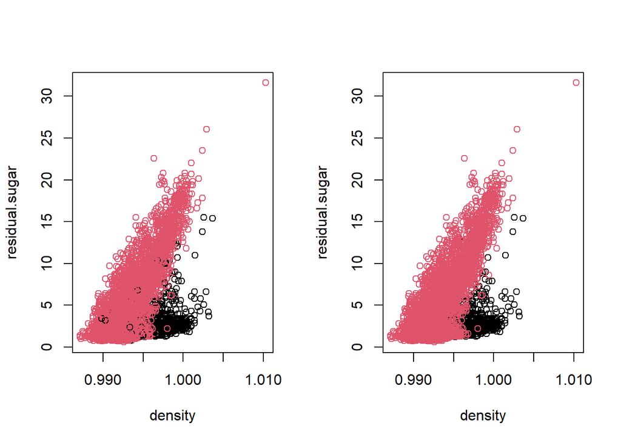

```r
# Comparació visual de com ha agrupat l'algorisme respecte als grups reals
par(mfrow=c(1,2))
plot(wine[c(7,4)], col=wine.k2$cluster)
plot(wine[c(7,4)], col=wine$type)
```

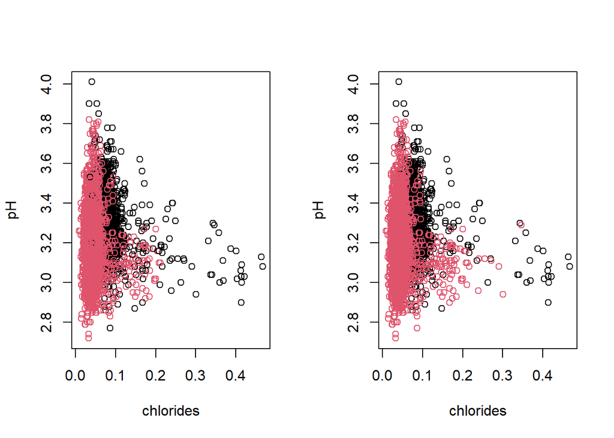

```r
# Comparació visual de com ha agrupat l'algorisme respecte als grups reals
par(mfrow=c(1,2))
plot(wine[c(5,8)], col=wine.k2$cluster)
plot(wine[c(5,8)], col=wine$type)
```

```r
# Taula amb els resultats de classificació del kmeans
table(wine.k2$cluster,wine$type)
```

```
##
##      red white
##   1 1559    60
##   2   23  4809
```

```r
# Precisió del model
(1559+4809)/(1559+4809+23+60)*100
```

```
## [1] 98.71338
```

```r
library(caret)
# També es pot observar amb la funció confusionMatrix
t <- table(wine.k2$cluster,wine$type)
rownames(t) <- c("red", "white")
confusionMatrix(t)
```

```
## Confusion Matrix and Statistics
##
##
##          red white
##   red   1559    60
##   white   23  4809
##
##                Accuracy : 0.9871
##                  95% CI : (0.9841, 0.9897)
##     No Information Rate : 0.7548
##     P-Value [Acc > NIR] : < 2.2e-16
##
##                   Kappa : 0.9655
##
##  Mcnemar's Test P-Value : 7.766e-05
##
##             Sensitivity : 0.9855
##             Specificity : 0.9877
##          Pos Pred Value : 0.9629
##          Neg Pred Value : 0.9952
##              Prevalence : 0.2452
##          Detection Rate : 0.2417
##    Detection Prevalence : 0.2510
##       Balanced Accuracy : 0.9866
##
##        'Positive' Class : red
##
```

### Regressió logística

```r
# Afegeix la variable type al data.frame normalitzat
wine.norm$type <- wine$type
str(wine.norm)
```

```
## 'data.frame':    6451 obs. of  11 variables:
##  $ fixed.acidity       : num  0.147 0.457 0.457 3.09 0.147 ...
##  $ volatile.acidity    : num  2.218 3.323 2.586 -0.361 2.218 ...
##  $ citric.acid         : num  -2.21 -2.21 -1.93 1.68 -2.21 ...
##  $ residual.sugar      : num  -0.753 -0.604 -0.668 -0.753 -0.753 ...
##  $ chlorides           : num  0.605 1.262 1.083 0.575 0.605 ...
##  $ total.sulfur.dioxide: num  -1.455 -0.867 -1.099 -0.992 -1.455 ...
##  $ density             : num  1.056 0.717 0.785 1.124 1.056 ...
##  $ pH                  : num  1.818 -0.116 0.258 -0.365 1.818 ...
##  $ sulphates           : num  0.205 1.036 0.828 0.343 0.205 ...
##  $ alcohol             : num  -0.916 -0.58 -0.58 -0.58 -0.916 ...
##  $ type                : Factor w/ 2 levels "red","white": 1 1 1 1 1 1 1 1 1 1 ...
```

```r
# Aplica la regressió logística
fit.full <- glm(type ~ fixed.acidity + volatile.acidity + citric.acid
              + residual.sugar + chlorides + total.sulfur.dioxide
              + density + pH + sulphates + alcohol,
              data=wine.norm, family=binomial())
```

```r
# Mostra els resultats de la regressió
summary(fit.full)
```

```
##
## Call:
## glm(formula = type ~ fixed.acidity + volatile.acidity + citric.acid +
##     residual.sugar + chlorides + total.sulfur.dioxide + density +
##     pH + sulphates + alcohol, family = binomial(), data = wine.norm)
##
## Deviance Residuals:
##     Min       1Q   Median       3Q      Max
## -4.1743   0.0010   0.0118   0.0345   4.5851
##
## Coefficients:
##                      Estimate Std. Error z value Pr(>|z|)
## (Intercept)            4.4927     0.2772  16.209  < 2e-16 ***
## fixed.acidity          1.1759     0.3234   3.636 0.000277 ***
## volatile.acidity      -0.8163     0.1662  -4.913 8.99e-07 ***
## citric.acid            0.5375     0.1938   2.773 0.005558 **
## residual.sugar         4.7503     0.4966   9.567  < 2e-16 ***
## chlorides             -0.8580     0.1427  -6.011 1.84e-09 ***
## total.sulfur.dioxide   2.8418     0.2617  10.858  < 2e-16 ***
## density               -7.3712     0.6560 -11.236  < 2e-16 ***
## pH                     0.5555     0.2439   2.277 0.022766 *
## sulphates             -0.2784     0.2046  -1.361 0.173660
## alcohol               -3.2183     0.4152  -7.751 9.15e-15 ***
## ---
## Signif. codes:  0 '***' 0.001 '**' 0.01 '*' 0.05 '.' 0.1 ' ' 1
##
## (Dispersion parameter for binomial family taken to be 1)
##
##     Null deviance: 7186.90  on 6450  degrees of freedom
## Residual deviance:  316.46  on 6440  degrees of freedom
## AIC: 338.46
##
## Number of Fisher Scoring iterations: 10
```

Segons la regressió logística, totes les variables seleccionades són significatives per a explicar la variable resposta type (p-valor < 0.05), amb l’excepció de la variable sulphates (p-valor = 0.17366).

```r
# Coeficients
coef(fit.full)
```

```
##          (Intercept)        fixed.acidity     volatile.acidity
##            4.4926562            1.1759120           -0.8163403
##          citric.acid       residual.sugar            chlorides
##            0.5374747            4.7502932           -0.8580403
## total.sulfur.dioxide              density                   pH
##            2.8418168           -7.3712380            0.5554830
##            sulphates              alcohol
##           -0.2784166           -3.2183069
```

Les variables que més contribueixen són density (-7.37) i residual.sugar (4.75).

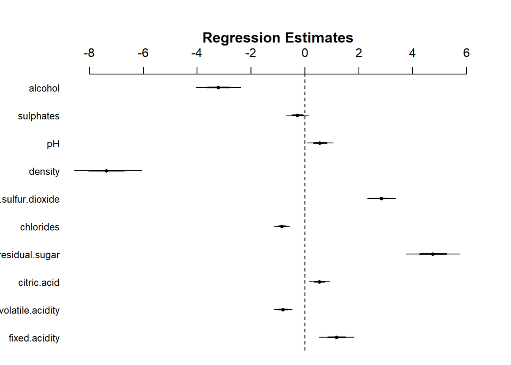

```r
library(arm)
# Mostra visualment els coeficients de les diferents variables
coefplot(fit.full, xlim=c(-8,6))
```